# UMA ANÁLISE DE PARTE DO ELEITORADO BOLSONARISTA EM 2018

Diego Cavalcante e Yury Machado

## OBJETO

- O perfil do eleitorado do presidente Jair Bolsonaro
- Suas percepções quanto às instituições democráticas a partir dos dados do Estudo Eleitoral Brasileiro (ESEB).

## OBJETIVOS

- Verificar a confiança dos eleitores de Jair Bolsonaro nas Instituições democráticas;
- Identificar a preferência de regime (democrático ou autoritário) dos eleitores de Jair Bolsonaro;
- Verificar o índice de confiança dos eleitores de Jair Bolsonaro nas FFAA;
- Calcular as chances de voto em Jair Bolsonaro em 1° e 2° turno a partir da percepção a cada uma das instituições e forma de regime (itens a. e b.).

## MÉTODO

A verificação empírica utilizou-se de:

- técnicas quantitativas de análise de dados
- estatística multivariada
- regressões logísticas binárias
- os resultados da regressão são dados em razão de chances (odds ratio)

## ÍNDICE DE CONFIANÇA

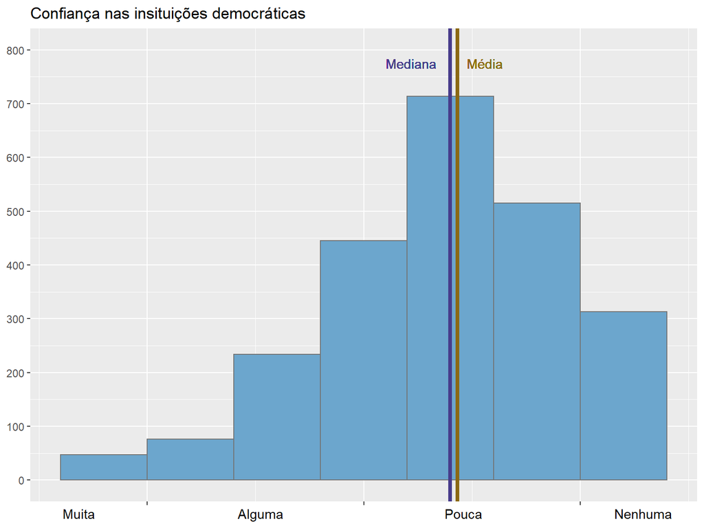

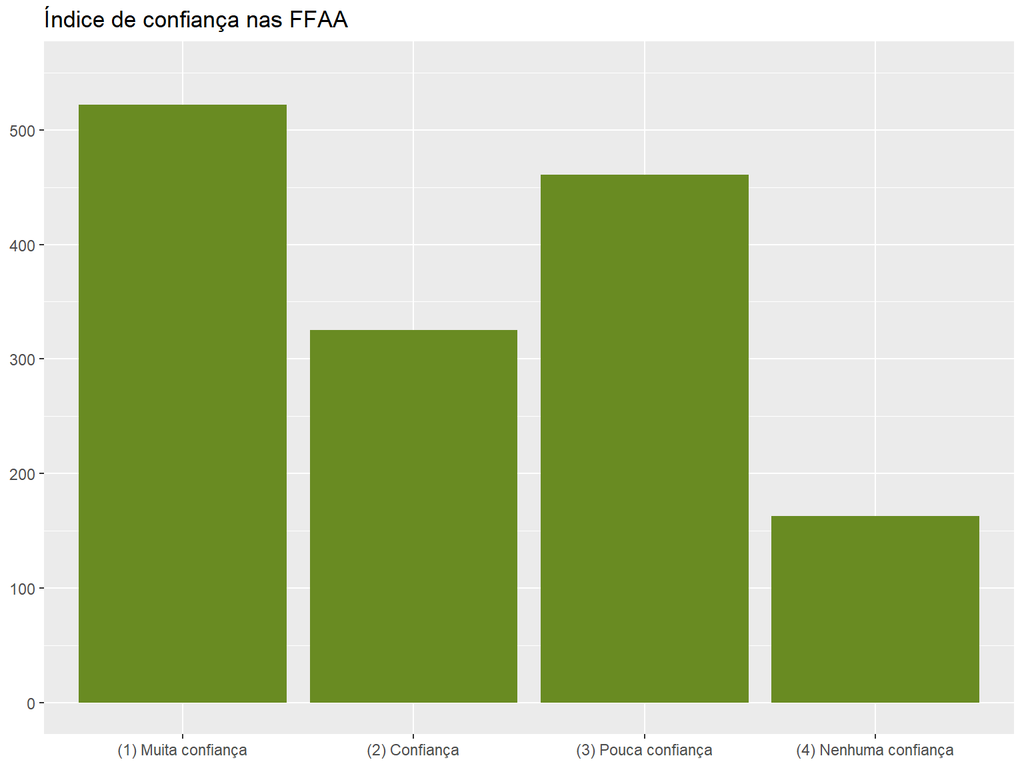